FJ

# Feidhelm Joyce

Business & Data Analyst  
Boston, MA

linkedin.com/in/feidhelmjoyce  
github.com/FeidhelmJ

DATA MINING FOR BUSINESS ANALYTICS

## Linear Regression

← Back to Data Mining for Business Analytics

```
import math as mth
import pandas as pd
import numpy as np
import matplotlib.pyplot as plt
import seaborn as sns
from sklearn.model_selection import train_test_split
from sklearn.linear_model import LinearRegression
from sklearn.metrics import mean_squared_error, r2_score
```

**Part I: Review of Mathematical Concepts**

Given the vectors: $u = \begin{pmatrix} 1 \\ -2 \\3 \end{pmatrix}$ and $v = \begin{pmatrix} 0 \\ 4\\ -1 \end{pmatrix}$, calculate the vector 3u - 2v.

```
u = np.array([1,-2,3])
v = np.array([0,4,-1])
q_1_result = 3*u - 2*v
print(q_1_result)
```

```
[  3 -14  11]
```

Answer $= \begin{pmatrix} 3 \\ -14 \\ 11 \end{pmatrix}$

Q.2

Let A = $ \begin{pmatrix} 1 & 2 \\ 3 & 4 \end{pmatrix}$ and B = $ \begin{pmatrix} -1 & 0 \\ 2 & -3 \end{pmatrix}$ Calculate 2A + $B^{T}$

```
A = np.array([[1,2],[3,4]])
B = np.array([[-1,0],[2,-3]])
q_2_result = 2*A + B.T
print(q_2_result)
```

```
[[1 6]
 [6 5]]
```

Answer $= \begin{pmatrix} 1 & 6\\ 6 & 5 \end{pmatrix}$

Q.3

Given matrices C = $ \begin{pmatrix} 1 & 0 & 2 \\ -1 & 3 & 1 \end{pmatrix}$ and D = $ \begin{pmatrix} 2 \\ 1 \\ -1 \end{pmatrix}$

Determine if the product CD is defined.

Calculate CD

C = 2 X 3 D = 3 X 1 Columns of C match Rows of D, therefore CD is defined.

```
C = np.array([[1,0,2],[-1,3,1]])
D = np.array([[2],[1],[-1]])
q_3_result = np.dot(C,D)
print(q_3_result)
```

```
[[0]
 [0]]
```

CD Answer $= \begin{pmatrix} 0\\ 0 \end{pmatrix}$

Q.4

Let A = $ \begin{pmatrix} 2 & 1 \\ 0 & 3 \end{pmatrix}$ and B = $ \begin{pmatrix} 1 & -1 \\ 2 & 0 \end{pmatrix}$ Calculate the product of AB

Calculate det(𝐴), det(𝐵), and det(𝐴𝐵). Verify that det(𝐴𝐵) = det(𝐴) det(𝐵)

```
A = np.array([[2,1],[0,3]])
B = np.array([[1,-1],[2,0]])
q_4_result = np.dot(A,B)
print(q_4_result)
```

```
[[ 4 -2]
 [ 6  0]]
```

AB Answer $= \begin{pmatrix} 4 & -2\\ 6 & 0 \end{pmatrix}$

```
DetA = np.linalg.det(A)
DetB = np.linalg.det(B)
DetAB = np.linalg.det(q_4_result)
print(DetA)
print(DetB)
print(DetAB)
```

```
6.0
2.0
12.0
```

DetA = 6

DetB = 2

DetAB = 12 Therefore DetAB = DetA X DetB

**Part II: Simple Linear Regression**

Download the file CreditCard.csv. (The documentation file posted with the assignment explains the meaning of most of the variables in this dataset, and it will be helpful for a few steps here, too).

Read this file using pandas

```
credit_card = pd.read_csv('CreditCard.csv')
```

```
pd.set_option('display.max_columns', None)
```

Describe the dataset.

- The dataset consists of 1,319 rows across 13 columns. 6 columns are int64 data types which are numeric columns only containing whole numbers. 3 columns are object data types which contain mostly string/text characters, 4 columns then are float64 data types which are numeric with decimals.
- Of these 13 columns, most can be classed as numeric variables however variables such as 'card', 'rownames', 'owner' & 'selfemp' are categorical.
- There are no missing values in the dataset.

How many rows and how many columns does your dataframe contain?

- 13 Columns
- 1,319 Rows

```
credit_card.head()
```

|  | rownames | card | reports | age | income | share | expenditure | owner | selfemp | dependents | months | majorcards | active |
| --- | --- | --- | --- | --- | --- | --- | --- | --- | --- | --- | --- | --- | --- |
| 0 | 1 | yes | 0 | 37.66667 | 4.5200 | 0.033270 | 124.983300 | yes | no | 3 | 54 | 1 | 12 |
| 1 | 2 | yes | 0 | 33.25000 | 2.4200 | 0.005217 | 9.854167 | no | no | 3 | 34 | 1 | 13 |
| 2 | 3 | yes | 0 | 33.66667 | 4.5000 | 0.004156 | 15.000000 | yes | no | 4 | 58 | 1 | 5 |
| 3 | 4 | yes | 0 | 30.50000 | 2.5400 | 0.065214 | 137.869200 | no | no | 0 | 25 | 1 | 7 |
| 4 | 5 | yes | 0 | 32.16667 | 9.7867 | 0.067051 | 546.503300 | yes | no | 2 | 64 | 1 | 5 |

```
credit_card.info()
```

```
<class 'pandas.core.frame.DataFrame'>
RangeIndex: 1319 entries, 0 to 1318
Data columns (total 13 columns):
 #   Column       Non-Null Count  Dtype
---  ------       --------------  -----
 0   rownames     1319 non-null   int64
 1   card         1319 non-null   object
 2   reports      1319 non-null   int64
 3   age          1319 non-null   float64
 4   income       1319 non-null   float64
 5   share        1319 non-null   float64
 6   expenditure  1319 non-null   float64
 7   owner        1319 non-null   object
 8   selfemp      1319 non-null   object
 9   dependents   1319 non-null   int64
 10  months       1319 non-null   int64
 11  majorcards   1319 non-null   int64
 12  active       1319 non-null   int64
dtypes: float64(4), int64(6), object(3)
memory usage: 134.1+ KB
```

Using a seed value based on last 3 digits of your BU ID, create a data partition. Assign approximately 60% of the records to your training set, and the other 40% to your validation (or test) set.

```
seed_value = 789
np.random.seed(seed_value)
```

```
training_set, test_set = train_test_split(credit_card, test_size=0.4, random_state=seed_value)
```

```
len(training_set)
```

```
791
```

```
len(test_set)
```

```
528
```

Why is it important to partition the data before doing any sort of in-depth analysis of the variables?

- If we build and test our model on the same dataset, it will perform unrealistically well because it has learned 'noise' instead of underlying patterns, this is called overfitting.
- By using a training set, the model can learn new patterns anf then by evaluated on 'new', unseen data from the test set.
- By analyzing all variables such as finding relationships, correlations and feature importance using the full dataset before splitting, the results will be unreliable as you're giving information from the test set into modeling decisions.

**Drilling Further**

Create a scatterplot that depicts income on the y-axis and dependents on the x-axis

```
training_set['income'] = training_set['income']*10000
```

```
test_set['income'] = test_set['income']*10000
```

```
income_dependents = sns.scatterplot(x = 'dependents', y = 'income', data = training_set)
plt.title('Income vs Dependents (Training Set)')
plt.xlabel('Dependents')
plt.ylabel('Income');
```

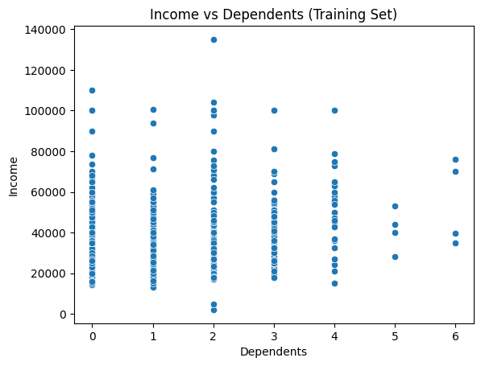

Add a best-fit line to this scatterplot. Use only your training set data to build this plot.

```
sns.lmplot(data = training_set, x = 'dependents', y = 'income', ci = None, line_kws={'color':'red'}, height = 5, aspect = 1.4)
plt.title('Income vs Dependents (Training Set)')
plt.xlabel('Dependents')
plt.ylabel('Income');
```

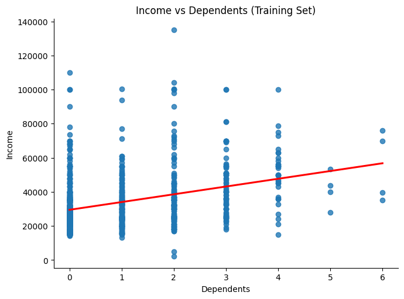

What does this plot suggest about the relationship between these variables? Does this make intuitive sense to you? Why or why not?

- The plot firstly shows us that the bulk of the applicants' income in the training set ranges from around 20,000 - 80,000 dollars and they have between 0 - 3 dependents.
- The plot doesn't suggest that there is much of a relationship between the two variables. The slope of the line of best fit slopes slightly upwards, implying a positive, but weak correlation between the two variables.
- This makes sense, having more or less dependents doesn't cause income to go up or down. There are applicants with income of over 100,000 with 0 dependents, and there are also applicants with income of 20,000 with 3 dependents.
4. Using training set data only, find the correlation between income and dependents.

1 What is this correlation?

- 0.3362445205679435

2 Is it a strong one?

- As noted above, this is a low/moderate positive relationship but there isn't a strong correlation between the two variables, hence the low value of around 0.33.

3 Is the correlation significant?

```
correlation_training = training_set['income'].corr(training_set['dependents'])
correlation_training
```

```
np.float64(0.3362445205679435)
```

5. Using your training set, create a simple linear regression model, with income as your outcome variable and dependents as your input variable. Summarize the results of your model.
- The model gives an Intercept value of roughly 29,483 which tells us that when the dependents value is 0, income for the applicant should be this value of 29,483.
- The model gives a Coefficient value of around 4551, which tells us that Income is predicted to increase by this value for each additional dependent.
- The formula would be Income = 29,483 + 4551(X), where X is the number of dependents.

```
regression_model_1 = LinearRegression()

X_train = training_set['dependents'].values.reshape(-1, 1)
y_train = training_set['income'].values

regression_model_1.fit(X_train, y_train)

print("Intercept:", regression_model_1.intercept_)
print("Coefficient:", regression_model_1.coef_[0])
```

```
Intercept: 29483.89045127469
Coefficient: 4551.447126651822
```

What are the minimum (most negative) and maximum (most positive) residual values in this model?

- Minimum residual -36486.784704578335
- Maximum residual 96413.21529542166

```
income_predictions = regression_model_1.predict(X_train)
residuals = y_train - income_predictions
print(residuals.min())
```

```
-36486.784704578335
```

```
print(residuals.max())
```

```
96413.21529542166
```

Find the observation whose rating generated the highest residual value in your model. What was that person’s actual income? What did the model predict that it would be? How is the residual calculated from the two numbers that you just found?

```
max_residual_row = residuals.argmax()
max_residual_row
```

```
np.int64(189)
```

```
actual_income = y_train[max_residual_row]
actual_income
```

```
np.float64(135000.0)
```

```
predicted_income = income_predictions[max_residual_row]
predicted_income
```

```
np.float64(38586.784704578335)
```

```
max_residual = residuals[max_residual_row]
max_residual
```

```
np.float64(96413.21529542166)
```

Find the observation whose rating generated the lowest (i.e. most negative) residual value. What was that person’s actual income? What did the model predict that it would be? How is the residual calculated from the two numbers that you just found?

```
min_residual_row = residuals.argmin()
min_residual_row
```

```
np.int64(156)
```

```
actual_income_min = y_train[min_residual_row]
actual_income_min
```

```
np.float64(2100.0)
```

```
predicted_income_min = income_predictions[min_residual_row]
predicted_income_min
```

```
np.float64(38586.784704578335)
```

```
min_residual = residuals[min_residual_row]
min_residual
```

```
np.float64(-36486.784704578335)
```

It looks like there are some cases where this model is quite a bit off the mark. Write a few sentences with your thoughts about why dependents might be an okay starting point, but may not perfectly predict a person’s income. (Try to be specific).

- Dependents, as noted, is just an okay starting point to try and predict a person's income. It is reasonable to assume that income is necessary to support dependents, and that greater financial resources are required to care for more dependents. However, to better understand each individual’s situation, additional variables should be included in the dataset.
- Variables such as gender & marital status would give more context to an individual's situation. For example, a person's income might be < 20,000 and they could have 2/3 dependents. It would be beneficial if we had information on this person's marital status, if he/she is married then it is likely that they are the primary carer for the dependents and his/her partner is the financial provider for the home. This is why we see extreme negative residual values in the model. If marital status is added as a variable, household income should also be added.
- Away from this however, dependents is still not a good predictor of income, especially in the modern world. Higher income does not necessarily lead to more dependents, nor does having more dependents guarantee higher income. According to NBC (2021), the average U.S. family size was 3.15—down from nearly 4 in the 1960s—and this downward trend is expected to continue. Smaller family sizes and lifestyle changes mean that many couples now choose not to have children at all.
- Factors such as employment status, education level, job type, and years of experience would be much better for predicting a person's income.

**Part III: Multiple Linear Regression**

Build a correlation table that depicts the correlations among all of the numerical variables that you might use as predictors (use your training set to build this).

```
credit_card.columns
```

```
Index(['rownames', 'card', 'reports', 'age', 'income', 'share', 'expenditure',
       'owner', 'selfemp', 'dependents', 'months', 'majorcards', 'active'],
      dtype='object')
```

```
correlation_table_variables = training_set[['reports','age', 'income','share', 'expenditure', 'dependents', 'months', 'majorcards', 'active']]
```

```
correlation_table = correlation_table_variables.corr()
correlation_table
```

|  | reports | age | income | share | expenditure | dependents | months | majorcards | active |
| --- | --- | --- | --- | --- | --- | --- | --- | --- | --- |
| reports | 1.000000 | 0.045218 | 0.029720 | -0.159314 | -0.131878 | -0.009007 | 0.029522 | -0.046797 | 0.243426 |
| age | 0.045218 | 1.000000 | 0.307631 | -0.110599 | 0.025204 | 0.189450 | 0.418395 | 0.013471 | 0.174662 |
| income | 0.029720 | 0.307631 | 1.000000 | -0.037055 | 0.313172 | 0.336245 | 0.085769 | 0.093749 | 0.160712 |
| share | -0.159314 | -0.110599 | -0.037055 | 1.000000 | 0.827663 | -0.039328 | -0.038867 | 0.046524 | -0.018881 |
| expenditure | -0.131878 | 0.025204 | 0.313172 | 0.827663 | 1.000000 | 0.116698 | -0.017147 | 0.078154 | 0.057319 |
| dependents | -0.009007 | 0.189450 | 0.336245 | -0.039328 | 0.116698 | 1.000000 | 0.051951 | 0.071561 | 0.088906 |
| months | 0.029522 | 0.418395 | 0.085769 | -0.038867 | -0.017147 | 0.051951 | 1.000000 | -0.072285 | 0.093228 |
| majorcards | -0.046797 | 0.013471 | 0.093749 | 0.046524 | 0.078154 | 0.071561 | -0.072285 | 1.000000 | 0.097126 |
| active | 0.243426 | 0.174662 | 0.160712 | -0.018881 | 0.057319 | 0.088906 | 0.093228 | 0.097126 | 1.000000 |

Are there any variable relationships that suggest that multicollinearity could be an issue here?

- Yes, the relationship between share & expenditure gives a value of 0.83 when rounded, this tells us that these two predictors are strongly correlated and this could lead to multicollinearity.

If so, for any strongly correlated variable pair, remove any variables that should be taken out of the model.

```
training_set = training_set.drop(columns = ['share'])
```

```
test_set = test_set.drop(columns = ['share'])
```

```
updated_correlation_table_variables = training_set[['reports','age', 'income','expenditure', 'dependents', 'months', 'majorcards', 'active']]
```

```
correlation_table_updated = updated_correlation_table_variables.corr()
correlation_table_updated
```

|  | reports | age | income | expenditure | dependents | months | majorcards | active |
| --- | --- | --- | --- | --- | --- | --- | --- | --- |
| reports | 1.000000 | 0.045218 | 0.029720 | -0.131878 | -0.009007 | 0.029522 | -0.046797 | 0.243426 |
| age | 0.045218 | 1.000000 | 0.307631 | 0.025204 | 0.189450 | 0.418395 | 0.013471 | 0.174662 |
| income | 0.029720 | 0.307631 | 1.000000 | 0.313172 | 0.336245 | 0.085769 | 0.093749 | 0.160712 |
| expenditure | -0.131878 | 0.025204 | 0.313172 | 1.000000 | 0.116698 | -0.017147 | 0.078154 | 0.057319 |
| dependents | -0.009007 | 0.189450 | 0.336245 | 0.116698 | 1.000000 | 0.051951 | 0.071561 | 0.088906 |
| months | 0.029522 | 0.418395 | 0.085769 | -0.017147 | 0.051951 | 1.000000 | -0.072285 | 0.093228 |
| majorcards | -0.046797 | 0.013471 | 0.093749 | 0.078154 | 0.071561 | -0.072285 | 1.000000 | 0.097126 |
| active | 0.243426 | 0.174662 | 0.160712 | 0.057319 | 0.088906 | 0.093228 | 0.097126 | 1.000000 |

If you removed any, how did you decide which ones to remove? If not, why did you keep the ones that you have left?

- As noted above, the relationship between share and expenditure gave a value of 0.83 when rounded which indicates the two predictors are strongly correlated.
- 'Share' represents the ratio of monthly credit card expenditure to yearly income, while 'expenditure' represents the average monthly credit card expenditure. Thinking about this, it is obvious that these two variables would be strongly correlated as when expenditure goes up, so does share. Given expenditure was a primary variable and not a derived variable, I decided that I would remove share from the model.

Using backward elimination, build a multiple regression model with the remaining data in your training set, with the goal of predicting the variable income. Start with all of the potential predictors that you have left (if you eliminated any variables in a previous step in this section, don’t bring them back – they’re gone!) (Be sure to use a function for this process, rather than a manual approach)

1. Show a summary of your resulting multiple linear regression model.

```
import statsmodels.api as sm
```

```
target_variable = training_set['income']
```

```
predictor_variables = training_set[['reports','age','expenditure','dependents','months','majorcards','active']]
```

```
predictor_variables = sm.add_constant(predictor_variables)
```

```
def backward_elimination(target_variable, predictor_variables, significance_level=0.05):

    X = predictor_variables.copy()
    y = target_variable
    while True:
        model = sm.OLS(y, sm.add_constant(X)).fit()
        p_values = model.pvalues.drop('const', errors='ignore')
        max_p_value = p_values.max()

        if max_p_value > significance_level:
            worst_var = p_values.idxmax()
            print(f"Removing '{worst_var}' (p = {max_p_value:.4f})")
            X = X.drop(columns=[worst_var])
        else:
            break
    final_model = sm.OLS(y, sm.add_constant(X)).fit()

    return final_model, X
```

```
final_model, final_predictors = backward_elimination(target_variable, predictor_variables.copy())
```

```
Removing 'months' (p = 0.3381)
Removing 'reports' (p = 0.1728)
Removing 'majorcards' (p = 0.1555)
```

```
print(final_model.summary())
```

```
                            OLS Regression Results
==============================================================================
Dep. Variable:                 income   R-squared:                       0.257
Model:                            OLS   Adj. R-squared:                  0.253
Method:                 Least Squares   F-statistic:                     67.87
Date:                Fri, 10 Oct 2025   Prob (F-statistic):           2.33e-49
Time:                        15:04:13   Log-Likelihood:                -8713.1
No. Observations:                 791   AIC:                         1.744e+04
Df Residuals:                     786   BIC:                         1.746e+04
Df Model:                           4
Covariance Type:            nonrobust
===============================================================================
                  coef    std err          t      P>|t|      [0.025      0.975]
-------------------------------------------------------------------------------
const        1.263e+04   1824.492      6.923      0.000    9050.217    1.62e+04
age           395.0249     52.477      7.528      0.000     292.013     498.036
expenditure    17.2627      1.959      8.811      0.000      13.417      21.109
dependents   3410.0242    427.290      7.981      0.000    2571.260    4248.788
active        224.4897     86.868      2.584      0.010      53.969     395.011
==============================================================================
Omnibus:                      323.761   Durbin-Watson:                   2.124
Prob(Omnibus):                  0.000   Jarque-Bera (JB):             1675.718
Skew:                           1.809   Prob(JB):                         0.00
Kurtosis:                       9.145   Cond. No.                     1.15e+03
==============================================================================

Notes:
[1] Standard Errors assume that the covariance matrix of the errors is correctly specified.
[2] The condition number is large, 1.15e+03. This might indicate that there are
strong multicollinearity or other numerical problems.
```

**Model metrics**

1. What is the total sum of squares for your model? (SST). This can be found by summing all of the squared differences from the mean for your outcome variable.
- Total Sum of Squares for the model (SST): 230,297,099,685.67636

```
y_mean = np.mean(target_variable)
SST = np.sum((target_variable - y_mean) ** 2)

print("Total Sum of Squares (SST):", SST)
```

```
Total Sum of Squares (SST): 230297099685.67636
```

What is the total sum of squares due to regression for your model? (SSR). This can be found by summing all the squared differences between the fitted values and the mean for your outcome variable. Do not use any other SSR definition, besides the one listed here in the previous sentence.

- Total Sum of Squares due to regression: 59,125,063,091.72237

```
fitted_value = final_model.fittedvalues
```

```
SSR = np.sum((fitted_value- y_mean) ** 2)
print("Total Sum of Squares (SSR):", SSR)
```

```
Total Sum of Squares (SSR): 59125063091.72237
```

What is your SSR/SST? Where can you also see this value in the summary of your regression model?

- SSR/SST = 0.2567338588823736
- In our OLS Regression model results, this is given as our R-Squared value.

```
R_Squared_manual = SSR/SST
print(R_Squared_manual)
```

```
0.2567338588823736
```

4. Getting from a t-value to a p-value. Choose one of the predictors from your model (it could be a numeric input variable or a single level from a categorical input). What is the t-value for that predictor?
- T - Value for 'Age' = 7.528.
- This strong t-statistic corresponds to a p-value < 0.001, showing that age is a statistically significant and positive predictor of income.

What is your model’s F-statistic? What does the F-Statistic measure?

- The model's F-statistic is 67.87
- The F-statistic compares how much variability your model explains versus how much is left unexplained relative to their degree of freedom. A larger F-statistic means the model explains much more variability than what would be expected by chance. The model's f-statistic of 67.87 indicates that the overall regression model is statistically significant and at least one of the predictors contributes significantly to explaining variation in income.

Make up a fictional consumer, and assign that person attributes for each variable used in your model. What does your model predict that this person’s income will be? To answer this, you can use a function in Python or just explain it using the equation and some simple math.

- Dave's predicted income = 54,579.20

```
Dave = pd.DataFrame({ 'age' :[44], 'expenditure' : [963], 'dependents' : [2], 'active' : [5]})
```

```
Dave = sm.add_constant(Dave)
```

```
Dave['const'] = 1.0
Dave = Dave[final_predictors.columns]

Dave_predicted_income = final_model.predict(Dave)

print("Predicted Income:", Dave_predicted_income.iloc[0])
```

```
Predicted Income: 54579.19587886575
```

Assess the accuracy of your model against both the training set and the validation set.

```
final_training_model = sm.OLS(target_variable, predictor_variables).fit()
```

```
target_variable_prediction = final_training_model.predict(predictor_variables)
```

```
test_set_predictors = test_set[['reports','age','expenditure','dependents','months','majorcards','active']]
test_set_target = test_set['income']
test_set_predictors = sm.add_constant(test_set_predictors, has_constant='add')
test_set_prediction = final_training_model.predict(test_set_predictors)
```

```
from sklearn.metrics import r2_score, mean_squared_error
```

```
R2_training = r2_score(target_variable, target_variable_prediction)
RSME_train = np.sqrt(mean_squared_error(target_variable, target_variable_prediction))
```

```
R2_test = r2_score(test_set_target, test_set_prediction)
RSME_test = np.sqrt(mean_squared_error(test_set_target, test_set_prediction))
```

```
print("R-squared (Training):", R2_training)
print("RMSE (Training):", RSME_train)
print("R-squared (Test):", R2_test)
print("RMSE (Test):", RSME_test)
```

```
R-squared (Training): 0.261265837195534
RMSE (Training): 14665.60839855841
R-squared (Test): 0.22929838913520773
RMSE (Test): 14681.17257425936
```